# Biostatistical Computing, PHC 6068

Monte Carlo methods

Zhiguang Huo (Caleb)

Monday Nov 30, 2020

# Sampling method

1. Monte Carlo methods.
   - Direct sampling.
   - Rejection sampling.
   - Importance sampling.
   - Sampling-importance resampling.
2. Markov chain Monte Carlo (MCMC).
   - Metropolis-Hasting.
   - Gibbs sampling.

# Notation

- Denote $p$, $q$ as unnormalized density function.
  - E.g. $p(x) = x(1 - x)$, $x \in (0, 1)$.
- Denote $p^*$, $q^*$ as normalized density function.
  - E.g. $p^*(x) = \frac{p(x)}{\int_x p(x) dx} = 6x(1 - x)$, $x \in (0, 1)$.
  - E.g. $q^*(x) = dnorm(x,0,1) = \frac{1}{\sqrt{2\pi}} \exp(-\frac{x^2}{2})$.

# Our targets

- Target 1, To generate Monte Carlo samples $x_m$ from a given probability distribution $p^*(x)$ or $p(x)$.
- Target 2, To estimate expectations of functions under this distribution, for example
  $$\mathbb{E}(g (x) | p^*(x)) = \int g(x) p^*(x) dx,$$
  - Examples:
  - $\mathbb{E} (x | p^*(x)) \doteq A$
  - $\mathbb{V}\mbox{ar} (x | p^*(x)) = \mathbb{E} [(x - A)^2| p^*(x)]$

# A simulation approach

Problem: We want to estimate
$$\mathbb{E}(g (x) | p^*(x)) = \int g(x) p^*(x) dx,$$
Given distribution $p^*(x)$.

Examples: $\mathbb{E} (x | p^*(x))$ or $\mathbb{V}\mbox{ar} (x | p^*(x))$

- To generate samples $x_m$ from a given probability distribution $p^*(x)$.
  - sample using R: (e.g. rnorm).
  - CDF transformation: sample from UNIF(0,1). Then use inverse CDF transformation.
- To estimate expectations of functions under this emperical distribution
  $$\mathbb{E}(g (x) | p^*(x)) \approx \frac{1}{M} \sum_{m=1}^M g(x^{(m)})$$
  - $M$ is number of Monte Carlo samples.
  - Via law of large number, this is valid.

# Un-normalized density function problems

- Unnormalized density function: $p(x) = \exp [ 0.4(x-0.4)^2 - 0.08x^4 ]$
  - $x \in (-4, 4)$

```r
p <- function(x, a=.4, b=.08){
  res <- exp(a*(x-a)^2 - b*x^4)
  res[res < -4 | res > 4] <- 0
  res
}
x <- seq(-4, 4, 0.01)
plot(x,p(x),type="l",  main = expression(p(x) == exp (0.4(x-0.4)^{2}  - 0.08 * x^{4})))
```

- Hard to compute the normalization factor $Z$.

```r
integrate(f = p, lower = -4, upper = 4)
```

```
## 7.852178 with absolute error < 9.1e-06
```

- Even if we know $Z$, it is still challenge to draw samples.
- A direct solution: partition the distribution into bins and direct sampling.

# Direct Sampling

- Partition the distribution into bins and perform direct sampling.

```r
x <- seq(-4, 4, 0.01)
plot(x,p(x),type="l",  main = expression(p(x) == exp (0.4(x-0.4)^{2}  - 0.08 * x^{4})))
```

[output not shown]

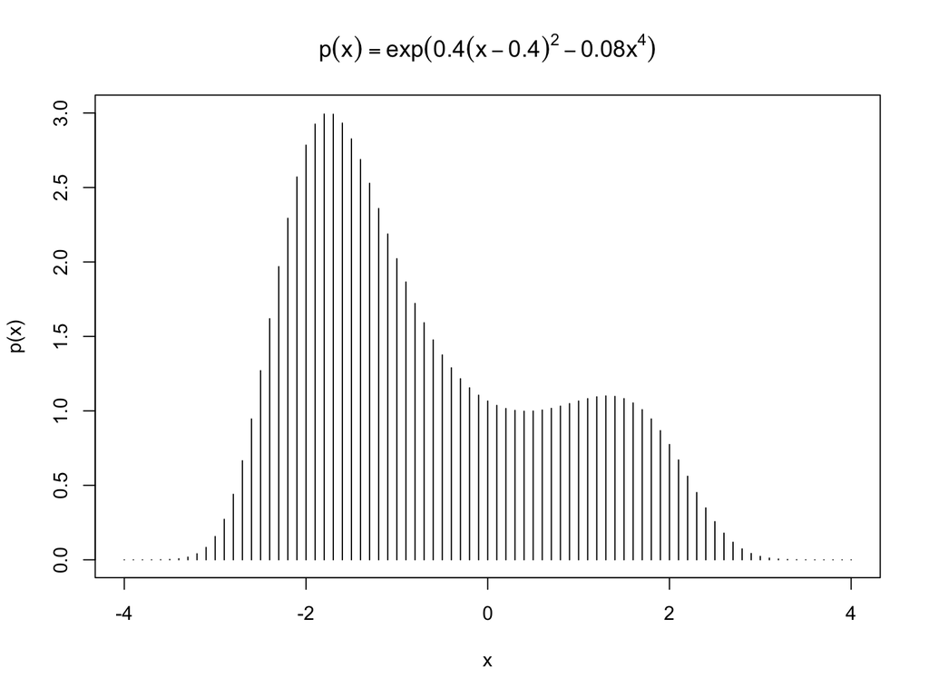

```r
x2 <- seq(-4, 4, 0.1)
plot(x,p(x),type="n",  main = expression(p(x) == exp (0.4(x-0.4)^{2}  - 0.08 * x^{4})))
segments(x2,0,x2,p(x2))
```

- Diffculty
  - Higher-dimensional: say $p = 5$
  - For each dimension, we divide the domain equally into $50$ bins
  - There will be $50^{5}$ sampling space, huge!

# Rejection sampling

- $p^*(x)$ is difficult to directly draw samples, but $p(x)$ is easy to evaluate..

(e.g., $p(x) = \exp [ 0.4(x-0.4)^2 - 0.08x^4 ]$)

- Sample from a simpler distribution $q^*(x)$.
- Rejection sampling algorithm:
1. $x \sim q^*(x)$
2. accept $x$ with prob $p(x)/c q^*(x)$:
   - Sample $u \sim \mbox{UNIF}(0,1)$, accept if $p(x)/c q^*(x) > u$.
3. Repeat Step 1 and 2 many times.

# Rejection sampling

```r
x <- seq(-4, 4, 0.01)
plot(x,p(x),type="l",  main = expression(p(x) == exp (0.4(x-0.4)^{2}  - 0.08 * x^{4})))
```

[output not shown]

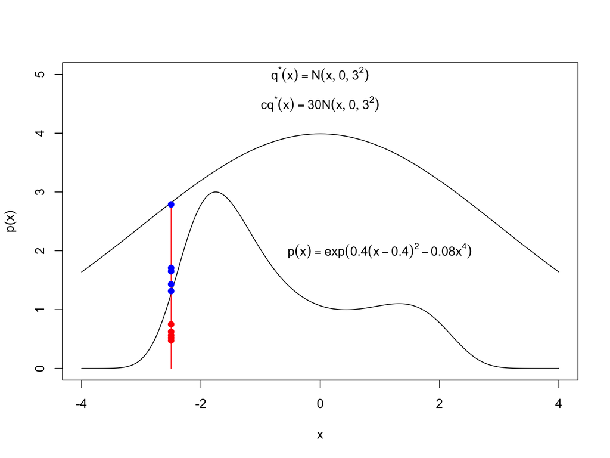

```r
x <- seq(-4, 4, 0.01)
qstar <- function(x, C = 30){
  C*dnorm(x,sd = 3)
}
plot(x,p(x),type="l", ylim = c(0,5))
curve(qstar,add = T)
text(0, 5, expression({q^"*"} (x) == N (x , 0, 3^2) ))
text(0, 4.5, expression({cq^"*"} (x) == 30* N (x , 0, 3^2) ))
text(1, 2, expression(p(x) == exp (0.4(x-0.4)^{2}  - 0.08 * x^{4})))
x0 <- -2.5 ## if we sampled -2.5 from the proposal distribution
segments(x0,0,x0,qstar(x0),col=2)
N <- 10
for(i in 1:N){
  set.seed(i)
  ay <- runif(1,0,qstar(x0))
  acol = ifelse(ay < p(x0),2,4)
  points(x0,ay,col=acol,pch=19)
}
```

# Rejection sampling

Proof:
$$\begin{align*}
p^*(x) &= \frac{p(x)}{Z} \\
&= \frac{p(x)}{\int_x p(x) dx} \\
&= \frac{[p(x)/c q^*(x)]q^*(x)}{\int_x [p(x)/c q^*(x)]q^*(x)dx} \\
\end{align*}$$

Interpretation of the numerator:

# Rejection sampling

```r
## rejection sampling
#p <- function(x, a=.4, b=.08){exp(a*(x-a)^2 - b*x^4)}
x <- seq(-4, 4, 0.1)
qstar <- function(x){
  dnorm(x,sd = 3)
}
# we can find M in this case:
C <- round(max(p(x)/qstar(x))) + 1; C
```

```
## [1] 28
```

```r
# number of samples
N <- 1000
# generate proposals and u
x.h <- rnorm( N, sd = 3)
u <- runif( N )
acc <- u < p(x.h) / (C * qstar(x.h))
x.acc <- x.h[ acc ]
# how many proposals are accepted
sum( acc ) /N
```

```
## [1] 0.285
```

```r
# calculate some statistics
c(m=mean(x.acc), s=sd(x.acc))
```

```
##          m          s
## -0.6207873  1.4258200
```

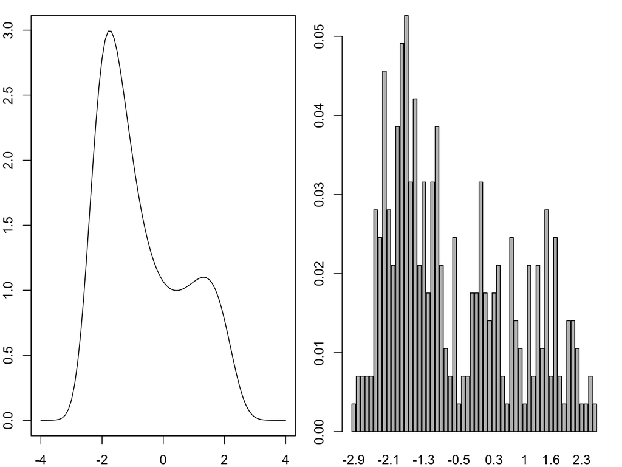

```r
par(mfrow=c(1,2), mar=c(2,2,1,1))
plot(x,p(x),type="l")
barplot(table(round(x.acc,1))/length(x.acc))
```

**Discussion:** What does the acceptance rate depend on?

# Importance sampling

Importance sampling is not a method for generating samples from $p(x)$ (target 1), it is just a method for estimating the expectation of a function $g(x)$ (target 2).

- Goal: want to calculate expectation of $\phi(x)$ under $p^*(x)$.
- Sampling from $p^*(x)$ is hard.
- Suppose we can sample from a simpler proposal distribution $q^*$ instead.
- If $q^*$ dominates $p^*$ (i.e., $q^*(x)>0$ whenever $p^*(x)>0$), we can sample from $q^*$ and reweight: $w(x) = \frac{p^*(x)}{q^*(x)}$

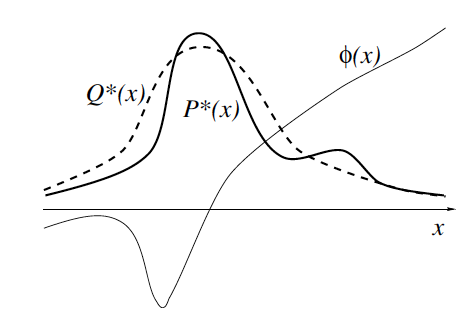

# Direct simulation approach

- Underlying distribution: $p(x)$ or $p^*(x) = \frac{p(x)}{Z}$.
- Function of interest $\phi (x)$.

$$\mathbb{E} (\phi (x) | p^* ) = \int \phi (x) p^*(x) dx$$

- If we can sample $x_m$ from $p^*(x)$, then we can use $\frac{1}{M} \sum_{m=1}^M \phi(x_m)$ to estimate $\mathbb{E} (\phi (x) | p^* )$

$$\hat{\mathbb{E}} (\phi (x) | p^* ) = \frac{1}{M}\sum_{m=1}^M\phi (x_m)$$

# Importance sampling, algorithm

- Underlying distribution: $p(x)$ or $p^*(x) = \frac{p(x)}{Z}$.
- Function of interest $\phi (x)$.

$$\mathbb{E} (\phi (x) | p^* ) = \int \phi (x) p^*(x) dx$$

- If we cannot sample $x_m$ from $p^*(x)$,
  - Rely on a proposed distribution (Sampler): $q^*(x)$.

$$\begin{align*}
\mathbb{E} (\phi (x) | p^* ) &= \int \phi (x) p^*(x) dx\\
&= \frac{\int \phi (x) p^*(x) dx}{\int p^*(x) dx}\\
&= \frac{\int [\phi (x) p(x)/Z] dx}{\int [p(x)/Z] dx}\\
&= \frac{\int [\phi (x) p(x)/q^*(x)] q^*(x) dx}{\int [p(x)/q^*(x)] q^*(x) dx},
\end{align*}$$

- $\mathbb{E} (\phi (x) | p^* )$ can be estimated using M draws $x_1, \ldots, x_M$ from $q^*(x)$ by the following expression.

$$\hat{\mathbb{E}} (\phi (x) | p^* ) = \frac{\frac{1}{M} \sum_{m=1}^M[\phi (x_m) p(x_m)/q^*(x_m)] }{ \frac{1}{M} \sum_{m=1}^M[p(x_m)/q^*(x_m)]}$$

$w(x_m) =\frac{p(x_m)}{q^*(x_m)}$

$$\hat{\mathbb{E}} (\phi (x) | p^* ) = \frac{ \sum_{m=1}^M \phi(x_m) w(x_m)}{ \sum_{m=1}^M w(x_m)}$$

- Importance ratio: $\frac{w(x_m)}{ \sum_{m=1}^M w(x_m)}$
- when $q^* = p$, the regular mean estimator is a special case of the importance sampling.

# Importance sampling, examples

- Problem setting:

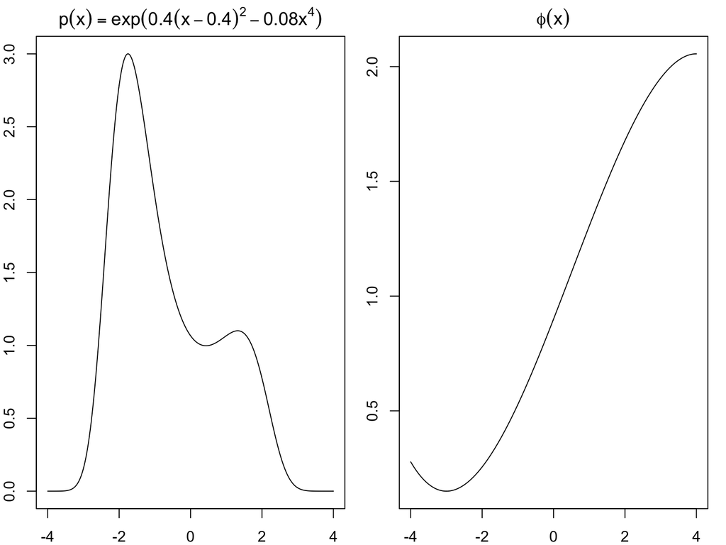

```r
par(mfrow=c(1,2), mar=c(2,2,2,1))

x <- seq(-4, 4, 0.01)
plot(x,p(x),type="l",  main = expression(p(x) == exp (0.4(x-0.4)^{2}  - 0.08 * x^{4})))

phi <- function(x){ (- 1/3*x^3 + 1/2*x^2 + 12*x - 12) / 30 + 1.3}
x <- seq(-4, 4, 0.01)
plot(x,phi(x),type="l",main= expression(phi(x)))
```

- $p(x) = \exp [0.4 (x - 0.4) ^ 2 - 0.08 x^4]$
- $\phi (x) = (- 1/3x^3 + 1/2x^2 + 12x - 12) / 30 + 1.3$ = right panel.

# Underlying solution

$$\begin{align*}
\mathbb{E} (\phi (x) | p^* ) &= \int \phi (x) p^*(x) dx\\
&= \frac{\int \phi (x) p^*(x) dx}{\int p^*(x) dx}\\
&= \frac{\int [\phi (x) p(x)/Z] dx}{\int [p(x)/Z] dx}\\
&= \frac{\int [\phi (x) p(x)] dx}{\int [p(x)] dx}\\
\end{align*}$$

```r
ep <- function(x) p(x)*phi(x)
truthE <- integrate(f = ep, lower = -4, upper = 4)$value/integrate(f = p, lower = -4, upper = 4)$value
truthE
```

```
## [1] 0.6971733
```

# Importance sampling, examples (2)

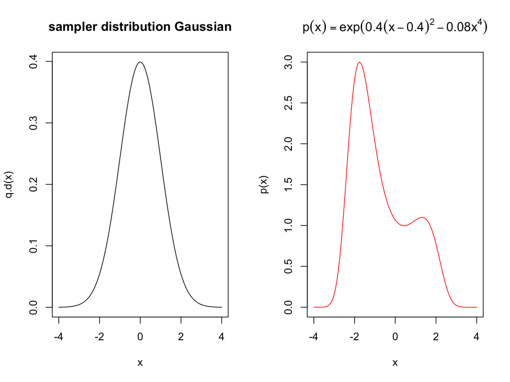

```r
q.r <- rnorm
q.d <- dnorm

par(mfrow=c(1,2))
plot(x,q.d(x),type="l",main='sampler distribution Gaussian')
curve(p, from = -4,to = 4 ,col=2 ,  main = expression(p(x) == exp (0.4(x-0.4)^{2}  - 0.08 * x^{4})))
```

```r
M <- 1000
x.m <- q.r(M)
ww <- p(x.m) / q.d(x.m)
qq <- ww / sum(ww) ## importance ratio
x.g <- phi(x.m)
sum(x.g * qq)
```

```
## [1] 0.7022795
```

# Number of samples for importance sampling

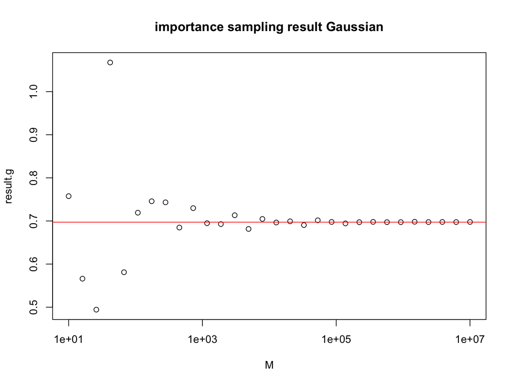

```r
M <- 10^seq(1,7,length.out = 30)

result.g <- numeric(length(M))
for(i in 1:length(M)){
  aM <- M[i]
  x.m <- q.r(aM)
  ww <- p(x.m) / q.d(x.m)

  qq.g <- ww / sum(ww)
  x.g <- phi(x.m)

  result.g[i] <- sum(x.g * qq.g)/sum(qq.g)
}

plot(M,result.g,log = "x", main='importance sampling result Gaussian')
abline(h = truthE, col = 2)
```

# Sampling from a narrow Gaussian distribution

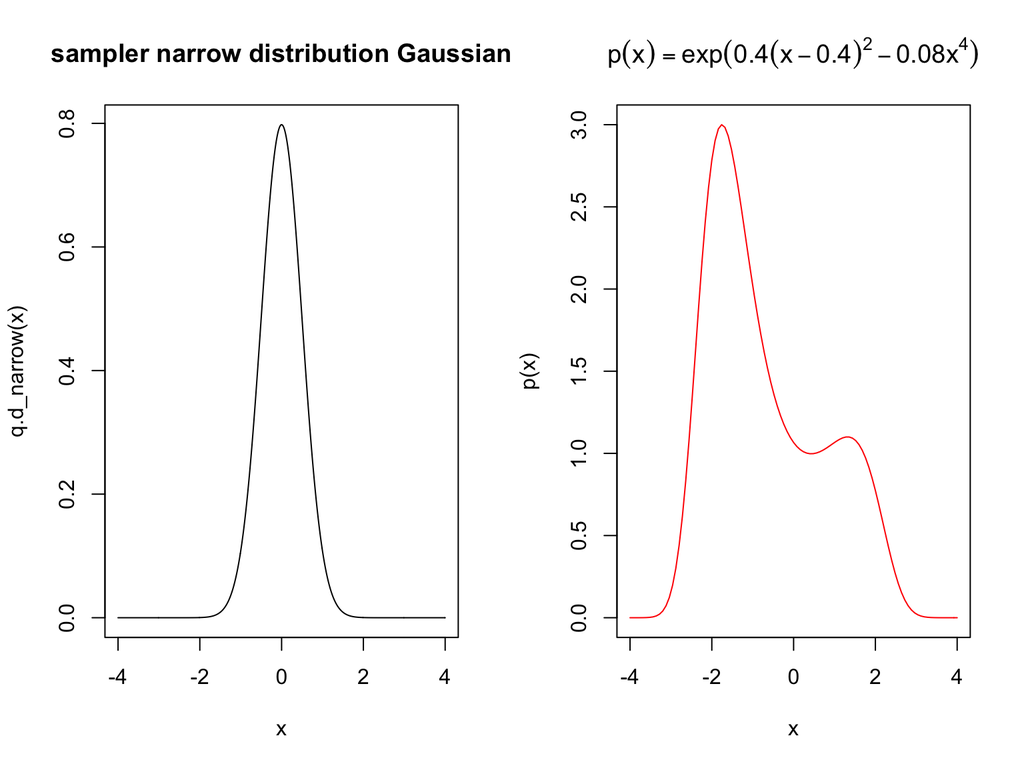

```r
q.r_narrow <- function(x){rnorm(x,0,1/2)}
q.d_narrow <- function(x){dnorm(x,0,1/2)}

par(mfrow=c(1,2))
plot(x,q.d_narrow(x),type="l",main='sampler narrow distribution Gaussian')
curve(p, from = -4,to = 4 ,col=2 ,  main = expression(p(x) == exp (0.4(x-0.4)^{2}  - 0.08 * x^{4})))
```

# Question

What will affect the estimation accuracy? - sample size $n$ - others?

# Number of samples for importance sampling (narrow Gaussian distribution)

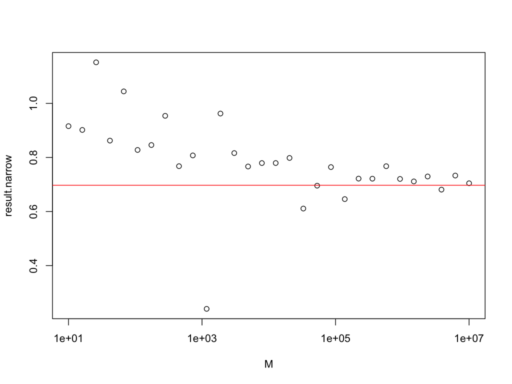

```r
M <- 10^seq(1,7,length.out = 30)

result.narrow <- numeric(length(M))
for(i in 1:length(M)){
  aM <- M[i]
  x.m <- q.r_narrow(aM)
  ww <- p(x.m) / q.d_narrow(x.m)

  qq.c <- ww / sum(ww)
  x.c <- phi(x.m)

  result.narrow[i] <- sum(x.c * qq.c)/sum(qq.c)
}
plot(M,result.narrow, log="x")
abline(h = truthE, col = 2)
```

# Remarks for importance sampling

- Want to estimate the $\mathbb{E} (\phi (x) | p^* )$.
- If the proposal density $q^*(x)$ is small in a region where $|\phi(x) p^*(x)|$ is large, it is quite possible that after many points $x_m$ have been generated, none of them fell in that region. This leads to a wrong estimate of $\mathbb{E} (\phi (x) | p^* )$.
- Importance sampler should have heavy tails.
- If $q^* (x)$ can be chosen such that $\frac{\phi p}{q^*}$ is roughly constant, then fairly precise estimates of the integral can be obtained.
- Importance sampling is not a useful method if the importance ratios vary substantially. The worst possible scenario occurs when the importance ratios are small with high probability but with a low probability are huge.

# Importance resampling (SIR)

- SIR: sampling-importance resampling. (target 1, generate samples)
- This is an alternative when rejection sampling constant $c$ is not immediately available.
- Algorithm (BDA3, reference)
  - Draw samples $x_1, \ldots, x_M \sim q^*(x)$.
  - Calculated importance weights $w_m = p(x_i)/q^*(x_i)$.
  - Normalize the weights as $W_m = \frac{w_m}{\sum_m w_m}$ (importance ratio).
  - Resample ($K$ out of $M$) from $\{ x_1, \ldots, x_M \}$ where $x_k, 1\le k \le K$ is drawn with probability $W_m$. (without replacement)

Remark:

- also see other people Resample ($M$ out of $M$) with replacement.

# Implement importance resampling (SIR)

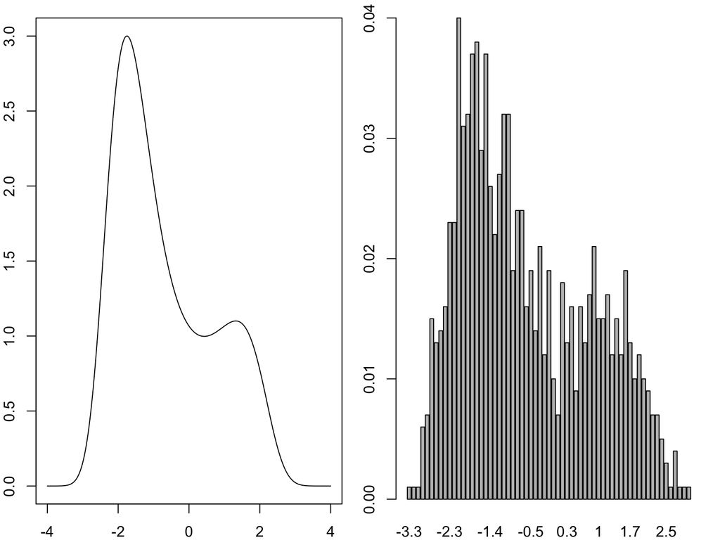

```r
#p <- function(x, a=.4, b=.08){exp(a*(x-a)^2 - b*x^4)}
x <- seq(-4, 4, 0.01)
plot(x,p(x),type="l")

qstar <- function(x){rep.int(0.125,length(x))} ## proposal distribution: uniform distribution.
N <- 10000
S <- 1000
x.qstar <- runif( N, -4, 4 )
ww <- p(x.qstar) / qstar(x.qstar)
qq <- ww / sum(ww) ## importance ratio
x.acc <-sample(x.qstar, size = S, prob=qq, replace=F)
par(mfrow=c(1,2), mar=c(2,2,1,1))
plot(x,p(x),type="l")
barplot(table(round(x.acc,1))/length(x.acc))
```

# Summarize

- Direct sampling. (target 1)
- Rejection sampling. (target 1)
- Importance sampling. (target 2)
- Sampling-importance resampling. (target 1)

# limitation of Monte Carlo method

- Direct sampling
  - Often hard to compute the normalization factor $Z$.
  - Hard to get rare events, especially in higher dimensional spaces.
- Rejection sampling, importance sampling.
  - Do not work well if the proposed distribution $q^*(x)$ is very different from $p(x)$.
  - Constructing a $q^*(x)$ similar to $p(x)$ can be difficult.
    - Making a good proposal usually requires knowledge of the analytic form of $p(x)$ - but if we had that, we wouldn’t even need to sample!
- Solution: instead of a fixed proposed distribution $q^*(x)$, we can use an adaptive proposal.

# Motivation of Metropolis-Hastings

- Drawbacks of rejection sampling and SIR are that it is difficult to propose an efficient distribution $q^*(x)$
- For rejection sampling, it is also difficult to find $M$.
- A smart idea is let the proposed distribution depends on the last accepted value.
- Instead of fixed $q(x')$, we use $q(x'|x)$ where $x'$ is the new state being sampled and $x$ is the previous sample.
- As $x$ changes, $q(x'|x)$ can also change (as a function of $x'$.)

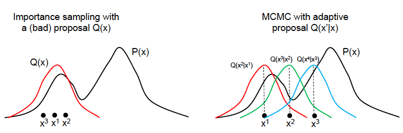

Comparison between importance sampling and Metropolis-Hastings

# Monte Carlo vs Markov Chain Monte Carlo

- Monte Carlo methods: simulation/sampling methods.
  - Simulation
  - Rejection sampling
  - SIR
- Markov Chain Monte Carlo: A type of Monte Carlo method – **next step sample depend on previous sample**.
  - Metropolis-Hastings
  - Gibbs Sampling

# Introduce MH algorithm

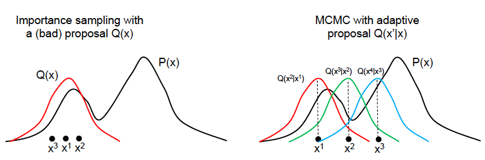

- Comparison between importance sampling and Metropolis-Hastings

- Draw a sample $x'$ from $q(x'|x)$, where $x$ is the previous sample.
- The new sample $x'$ is accepted or rejected with some probability $A(x'|x)$.
  $$A(x'|x) = \min \bigg(1, \frac{p(x')q(x|x')}{p(x)q(x'|x)} \bigg)$$
- $\frac{p(x')}{q(x'|x)}/\frac{p(x)}{q(x|x')}$ is a ratio of importance sampling weights.

# MH algorithm

- Initialize our parameters $x^0$.
- Given an accepted value $x^{t-1}$
  1. Draw $x \sim q(\cdot|x^{t-1})$.
  2. Accept $x$ with probability $A(x|x^{t-1}) = \min \bigg(1, \frac{p(x)q(x^{t-1}|x)}{p(x^{t-1})q(x|x^{t-1})} \bigg)$, and if accepted, set $x^t = x$.
     - Draw $u \sim UNIF(0,1)$.
     - If $u < A(x|x^{t-1})$, accept.
  3. If we didn’t accept $x$, set $x^t = x^{t - 1}$
- We repeat $T$ times ($t = 1, \ldots, T$).

# Implementation of MH algorithm

- target distribution: $p(x) = \exp [ 0.4(x-0.4)^2 - 0.08x^4 ]$
- sampling distribution: $q(x^{(t)}) = dnorm(x^{(t)},x^{(t-1)},1)$

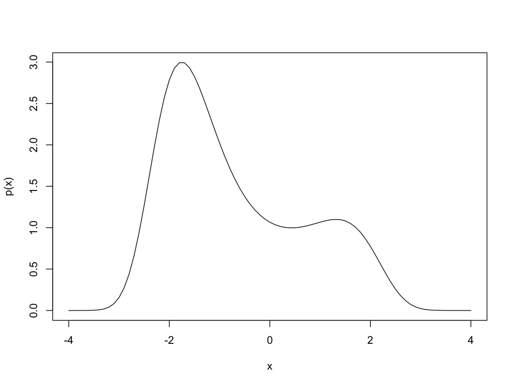

```r
p <- function(x, a=.4, b=.08){exp(a*(x-a)^2 - b*x^4)}
x <- seq(-4, 4, 0.1)
plot(x,p(x),type="l")
```

```r
N <- 10000
x.acc5 <- rep.int(NA, N)
u <- runif(N)
acc.count <- 0
std <- 1 ## Spread of proposal distribution
xp <- 0; ## Starting value
for (ii in 1:N){
  set.seed(ii)
  xc <- rnorm(1, mean=xp, sd=std) ## xp previous sample; xc: current sample
  alpha <- min(1, (
      p(xc) /dnorm(xc, mean=xp,sd=std) /
      (p(xp) / dnorm(xp, mean=xc,sd=std))
                  )
               )
  x.acc5[ii] <- xp <- ifelse(u[ii] < alpha, xc, xp)
  ## find number of acccepted proposals:
  acc.count <- acc.count + (u[ii] < alpha)
}
## Fraction of accepted *new* proposals
acc.count/N
```

```
## [1] 0.737
```

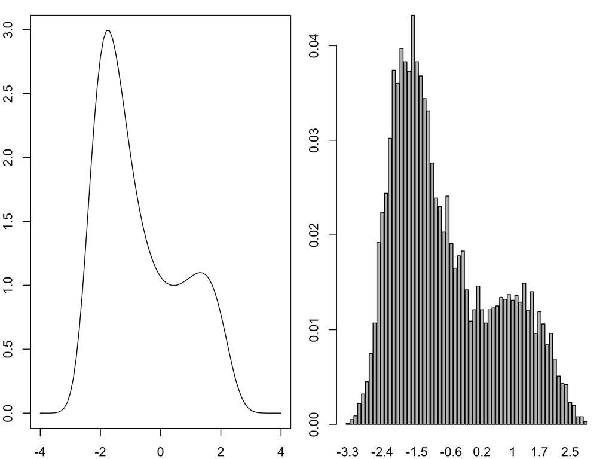

```r
par(mfrow=c(1,2), mar=c(2,2,1,1))
plot(x,p(x),type="l")
barplot(table(round(x.acc5,1))/length(x.acc5))
```

# Check samples from MH

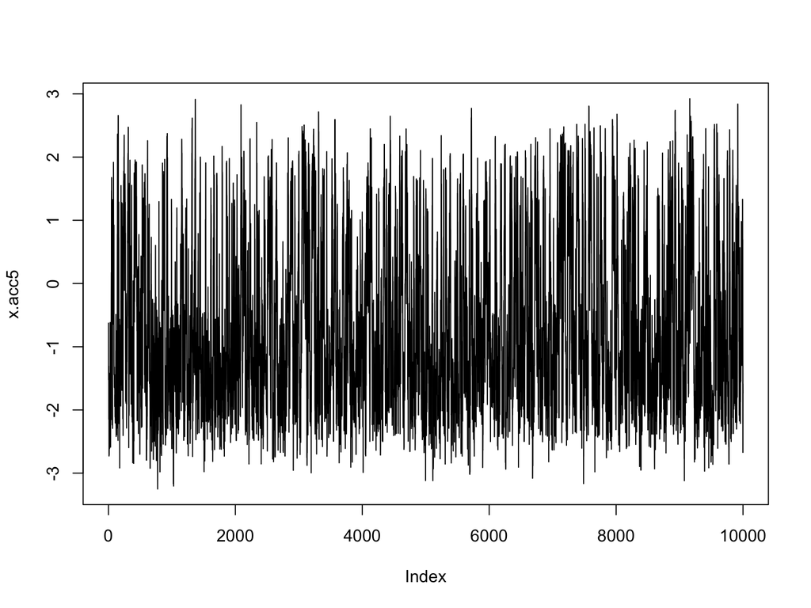

```r
plot(x.acc5,type="l")
```

- Good convergence.
- Samples are focused at the underlying distribution (stationary distribution)

# Vary some parameters in MH

- Burnin period: disgard intial samples since they may not be in the stationary distribution
  - initial x = 8?
- Play with variance? (doesn’t converge to the stationary distribution with limited sample size)
  - sd = 0.1
  - sd = 0.01

Trade off between acceptance rate and convergence.

- How many samples (empirically):
  - total 10,000 samples.
  - 500 burnin samples.

# Remove initial values for burnin period

```r
N <- 1000
x.acc5 <- rep.int(NA, N)
u <- runif(N)
acc.count <- 0
std <- 1 ## Spread of proposal distribution
xp <- 8; ## Starting value
for (ii in 1:N){
  xc <- rnorm(1, mean=xp, sd=std) ## xp previous sample; xc: current sample
  alpha <- min(1, (
      p(xc) /dnorm(xc, mean=xp,sd=std) /
      (p(xp) / dnorm(xp, mean=xc,sd=std))
                  )
               )
  x.acc5[ii] <- xp <- ifelse(u[ii] < alpha, xc, xp)
  ## find number of acccepted proposals:
  acc.count <- acc.count + (u[ii] < alpha)
}
## Fraction of accepted *new* proposals
acc.count/N
```

```
## [1] 0.73
```

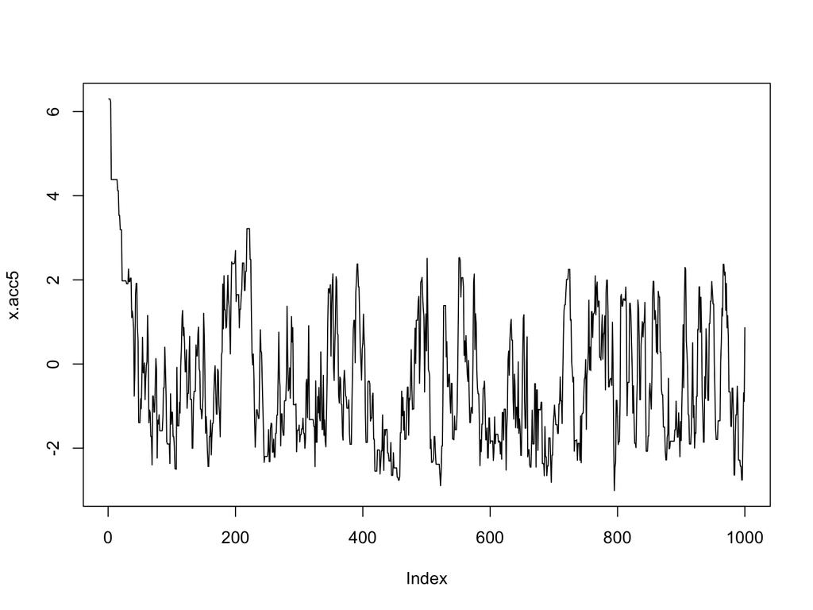

```r
plot(x.acc5,type="l")
```

# Doesn’t converge

```r
N <- 1000
x.acc5 <- rep.int(NA, N)
u <- runif(N)
acc.count <- 0
std <- 0.1 ## Spread of proposal distribution
xc <- 0; ## Starting value
for (ii in 1:N){
  xp <- rnorm(1, mean=xc, sd=std) ## proposal
  alpha <- min(1, (p(xp)/p(xc)) *
                 (dnorm(xc, mean=xp,sd=std)/dnorm(xp, mean=xc,sd=std)))
  x.acc5[ii] <- xc <- ifelse(u[ii] < alpha, xp, xc)
  ## find number of acccepted proposals:
  acc.count <- acc.count + (u[ii] < alpha)
}
## Fraction of accepted *new* proposals
acc.count/N
```

```
## [1] 0.971
```

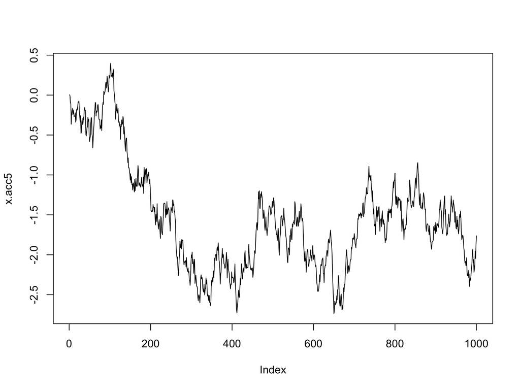

```r
plot(x.acc5,type="l")
```

# Why MH converge?

Concepts:

# Why MH converge?

- In MH we draw sample $x'$ according to $q(x'|x)$, then we accept/reject according to $A(x'|x)$.
- The transition kernel is $T(x'|x) = q(x'|x) A(x'|x)$.
- $A(x'|x) = \min \bigg(1, \frac{p(x')q(x|x')}{p(x)q(x'|x)} \bigg)$
- Proof:
  - If $A(x'|x) \le 1$, then $\frac{p(x')q(x|x')}{p(x)q(x'|x)} \le 1$, $\frac{p(x)q(x'|x)}{p(x')q(x|x')} \ge 1$, $A(x|x') = 1$.

$$A(x'|x) = \frac{p(x')q(x|x')}{p(x)q(x'|x)}$$
$$p(x)q(x'|x) A(x'|x) = p(x')q(x|x')$$
$$p(x)q(x'|x) A(x'|x) = p(x')q(x|x') A(x|x')$$
$$p(x)T(x'|x) = p(x')T(x|x')$$
The last line is called detailed balance condition.

$$\int_{x} p(x)T(x'|x) dx = \int_{x} p(x')T(x|x') dx$$
$$p(x') = \int_{x} p(x)T(x'|x) dx$$

Since p(x) is the true distribution. MH algorithm will eventually converges to the true distribution.

# Special cases for MH

- Metropolis algorithm:
  - The proposed distribution is symmetrical, e.g. $q(x'|x) = q(x|x')$ for all pairs (x,x’). In this case the acceptance probability is $A(x'|x) = \min (1, \frac{p(x')}{p(x)})$
- Random-walk Metropolis:
  - A popular choice for proposal in a Metropolis algorithm is $q(x'|x) = g(x-x')$ where g is symmetric.
- Independence sampler:
  - The proposed distribution $q(x'|x) = q(x')$ doesn’t depend on $x$. The acceptance probability becomes $A(x'|x) = \min(1, \frac{p(x')}{p(x)} \frac{q(x)}{q(x')})$. This works well when $q$ is a good approximation to $p$.
- Gibbs sampling:
  - $q(x'|x)$ is the conditional probability given all other variables. $A(x'|x) = 1$.

# Markov Chain Monte Carlo (MCMC)

- We always need to pay attention to:
  - Burn-in period
  - Monitor convergence
- Question: Since we know samples are correlated from Metropolis-Hastings algorithm, can we still estimate an estimator $\theta$ by sample average?
  - Yes, if the underlying density function is also about $\theta$.
  - Weak law of large number (WLLN) is still valid if samples are correlated, the only requirement is the samples are identical distributed.
- Another popular algorithm: Gibbs sampling.